# 3. Results Analysis and Visualization

#### 5.6.2.4 EFM-19 (Inavolisib x Giredestrant)

🔍 Zoom In for Details

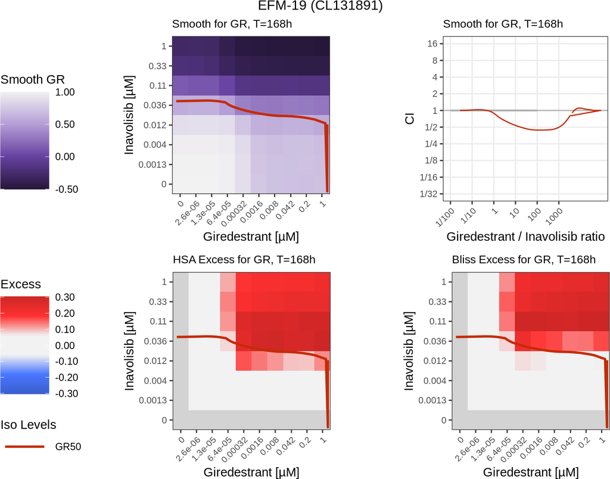

#### 5.6.2.5 MCF-7 (Everolimus x Giredestrant)

🔍 Zoom In for Details

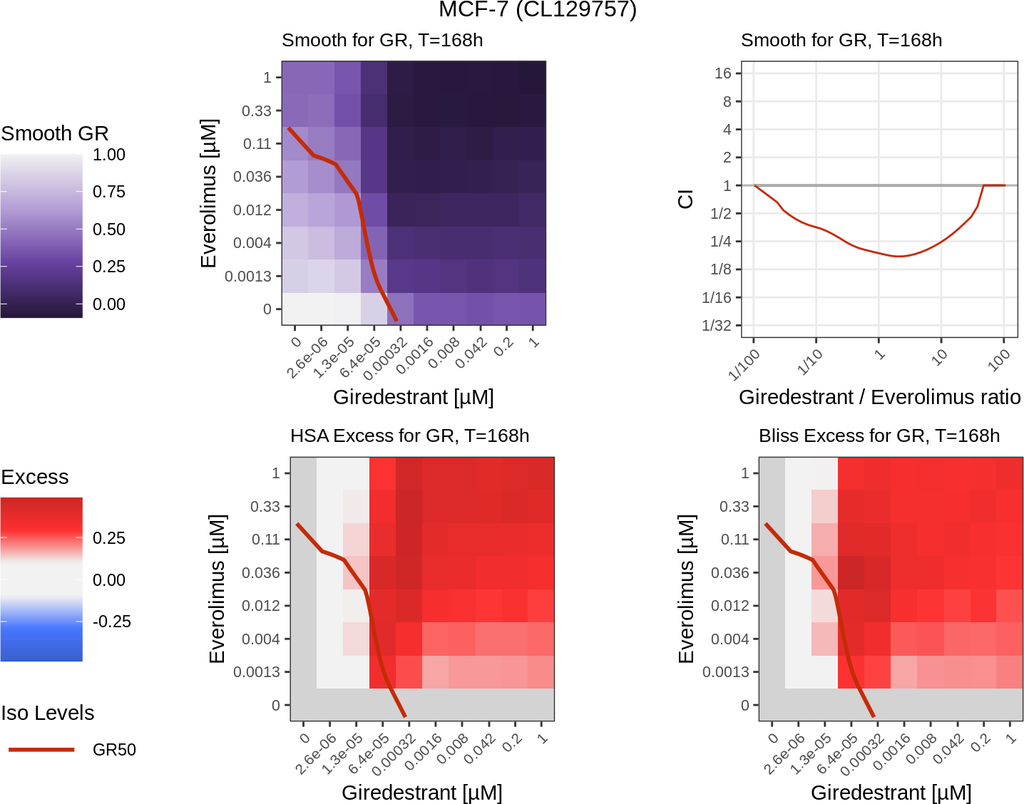

#### 5.6.2.6 MCF-7 (Inavolisib x Giredestrant)

🔍 Zoom In for Details

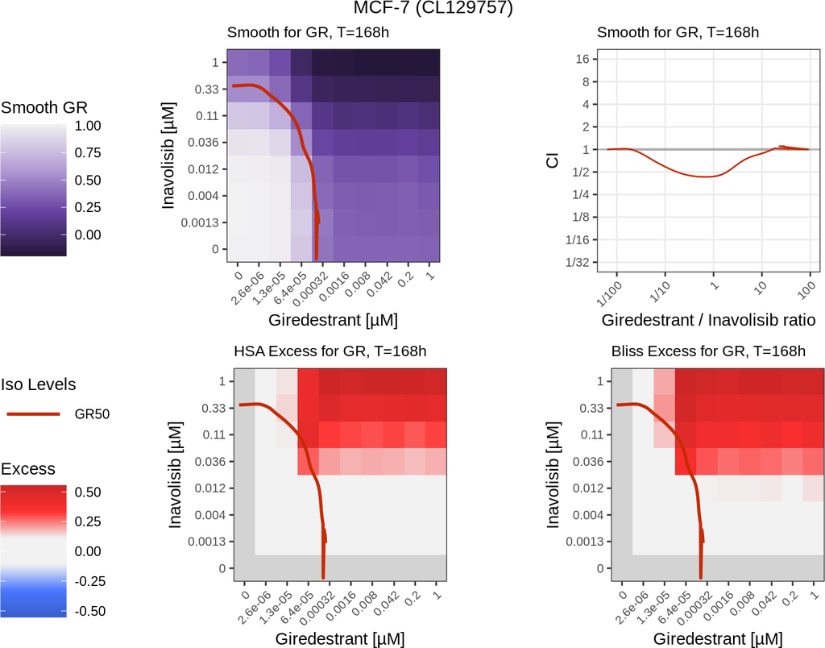

#### 5.6.2.7 T-47D (Everolimus x Giredestrant)

🔍 Zoom In for Details

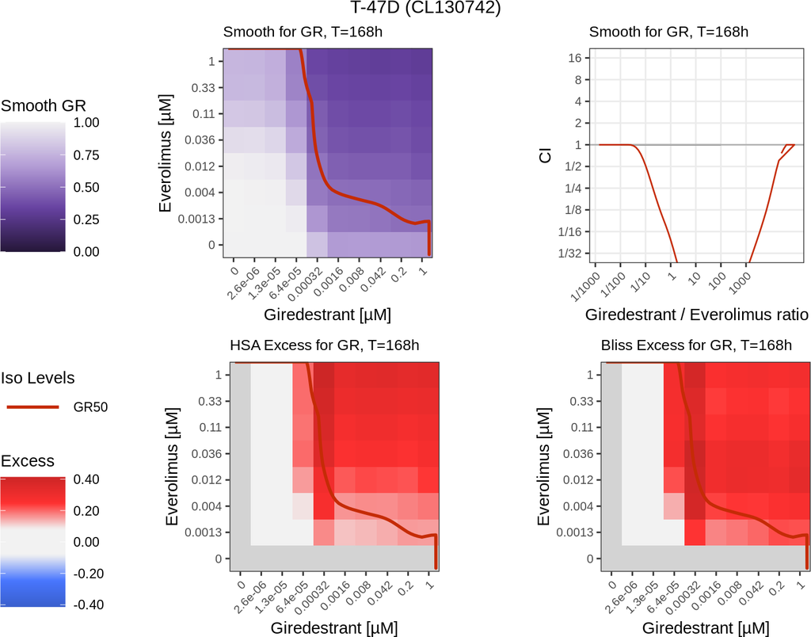

#### 5.6.2.8 T-47D (Inavolisib x Giredestrant)

🔍 Zoom In for Details

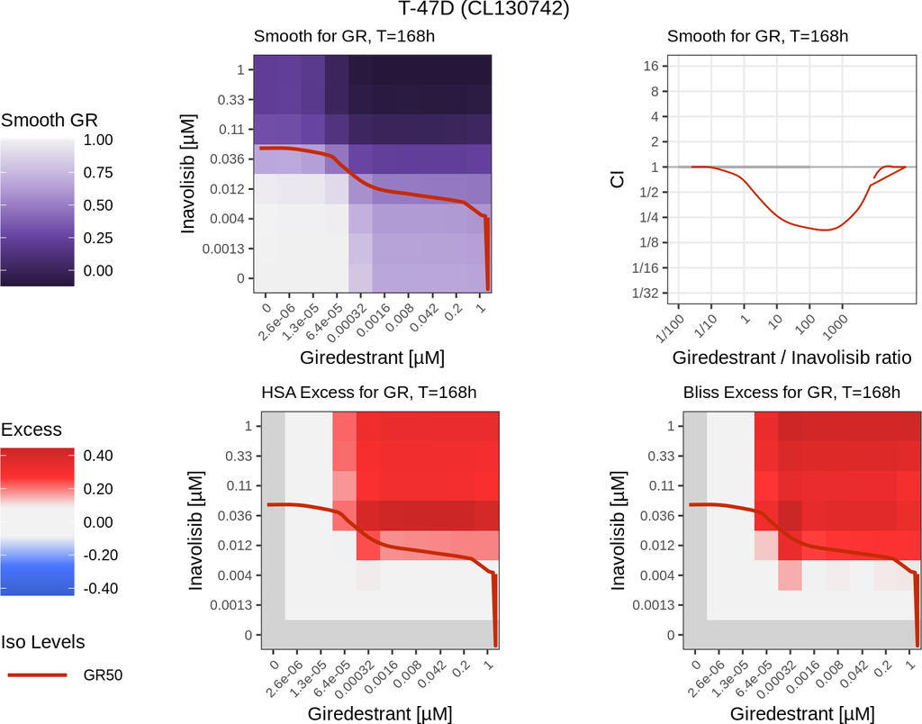

## 5.7 Data Analysis - Reference Isobolograms for Combination Data

This section provides a detailed comparison of synergy for each drug combination across all tested cell lines. The plots are organized by synergy metric (e.g., Smooth response, HSA Excess, Bliss Excess). Each plot panel shows the synergy heatmaps for one drug combination across multiple cell lines, making it easy to spot differences in response.

**What to look for:**

- **Comparing Cell Lines:** Look at the panel of heatmaps to see which cell lines show the strongest synergistic or antagonistic responses for the selected drug combination.
- **Interpreting Each Heatmap:**
- For **benefit score heatmaps (HSA/Bliss Excess)**, look for **regions of warm colors (red/orange)**, which indicate combination benefit. **Regions of cool colors (blue)** indicate antagonism.
- For **smoothed response heatmaps**, look for a strong dose-dependent effect (darkening color) to confirm drug activity.
- **Interpreting the Isobologram Lines:** The lines on the heatmap show the dose combinations needed to achieve a certain effect level.
- The **dashed line** represents the theoretical line of additivity.
- The **solid line** represents the measured effect.
- **Synergy** is indicated when the solid line **bows inwards (is concave)**, meaning less of each drug was needed to achieve the effect.
- **Antagonism** is indicated when the solid line **bows outwards (is convex)**.

```r
cellline_name_vec <- sort(unique(response_metrics_excess[["CellLineName"]]))

tab_grid <-
  unique(response_metrics_excess[, .SD, .SDcols = c("DrugName", "DrugName_2")])
setorder(tab_grid)
setnames(tab_grid, old = c("DrugName", "DrugName_2"),
                     new = c("drug1_name", "drug2_name"))

ls_names <- sprintf("%s x %s", tab_grid$drug1_name, tab_grid$drug2_name)
ls_names <- vapply(ls_names, function(i) escape_special_characters(i),
                  FUN.VALUE = character(1), USE.NAMES = FALSE)

ls_plt_RV <- lapply(names(get_combo_excess_field_names()), function(metric) {
  ls_plt <- pmap(tab_grid,
                 heatmap_combo_with_isoref_panel,
                 dt_excess = response_metrics_excess,
                 dt_isobolograms = response_metrics_isobolograms,
                 cl_names = cellline_name_vec,
                 iso_levels = "0.5",
                 metric = metric,
                 normalization_type = "RV")
  names(ls_plt) <- ls_names
  ls_plt
})
names(ls_plt_RV) <- names(get_combo_excess_field_names())
```

```r
ls_plt_GR <- lapply(names(get_combo_excess_field_names()), function(metric) {
  ls_plt <- pmap(tab_grid,
                 heatmap_combo_with_isoref_panel,
                 dt_excess = response_metrics_excess,
                 dt_isobolograms = response_metrics_isobolograms,
                 cl_names = cellline_name_vec,
                 iso_levels = "0.5",
                 metric = metric,
                 normalization_type = "GR")
  names(ls_plt) <- ls_names
  ls_plt
})
names(ls_plt_GR) <- names(get_combo_excess_field_names())
```

### 5.7.1 Smooth

#### 5.7.1.1 Relative Viability

##### 5.7.1.1.1 Everolimus x Giredestrant

🔍 Zoom In for Details

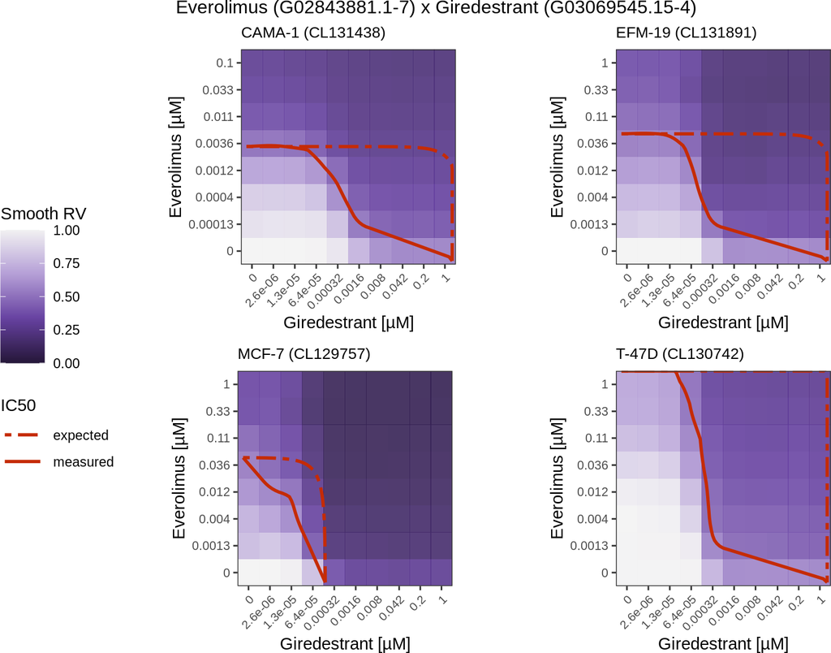

##### 5.7.1.1.2 Inavolisib x Giredestrant

🔍 Zoom In for Details

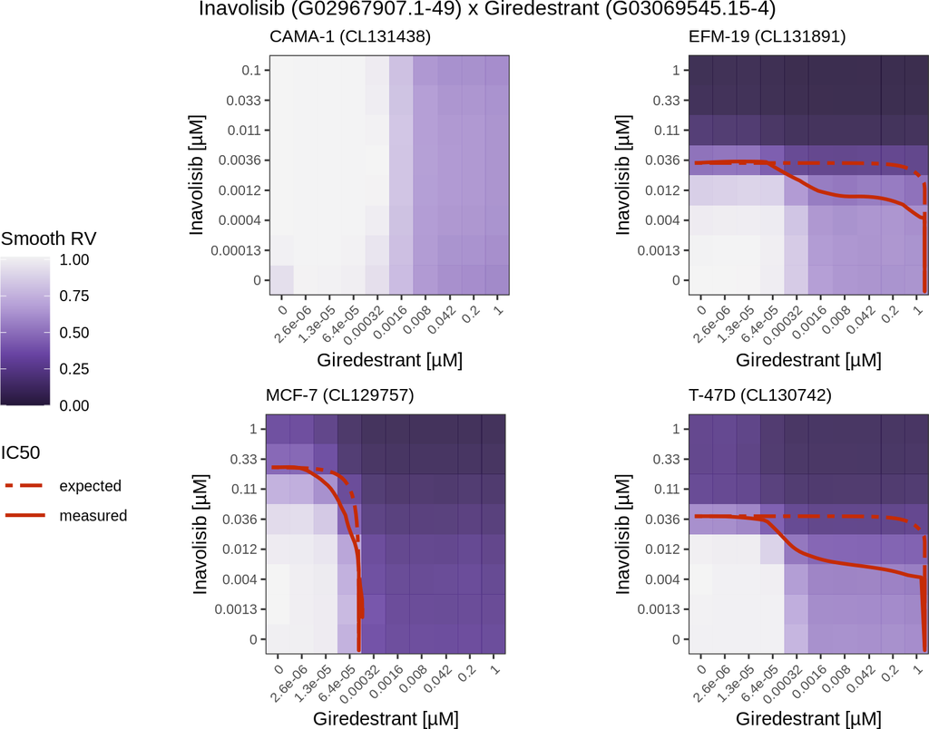

#### 5.7.1.2 GR Value

##### 5.7.1.2.1 Everolimus x Giredestrant

🔍 Zoom In for Details

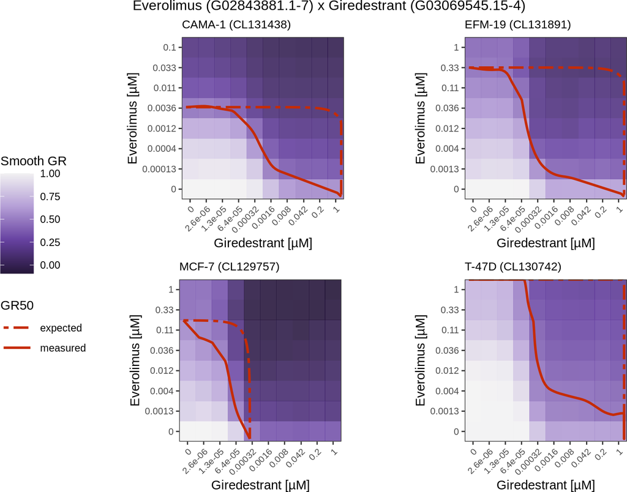

##### 5.7.1.2.2 Inavolisib x Giredestrant

🔍 Zoom In for Details

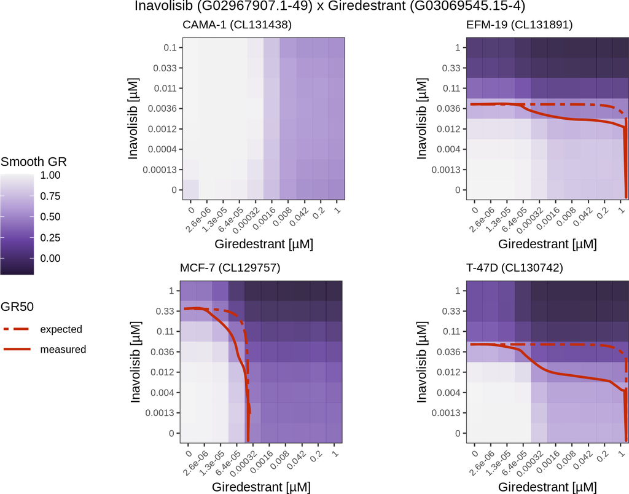

### 5.7.2 HSA Excess

#### 5.7.2.1 Relative Viability

##### 5.7.2.1.1 Everolimus x Giredestrant

🔍 Zoom In for Details

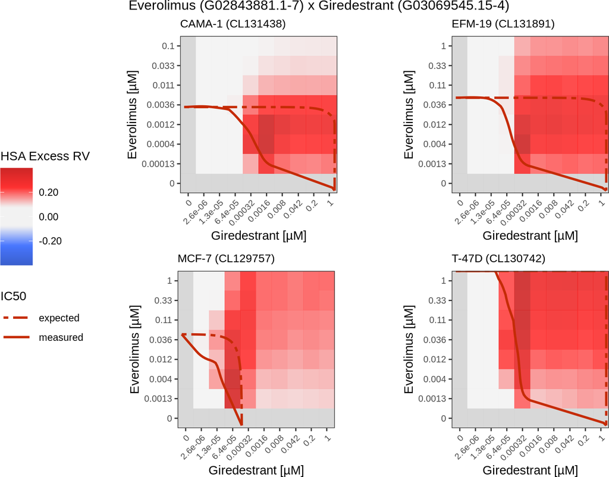

##### 5.7.2.1.2 Inavolisib x Giredestrant

🔍 Zoom In for Details

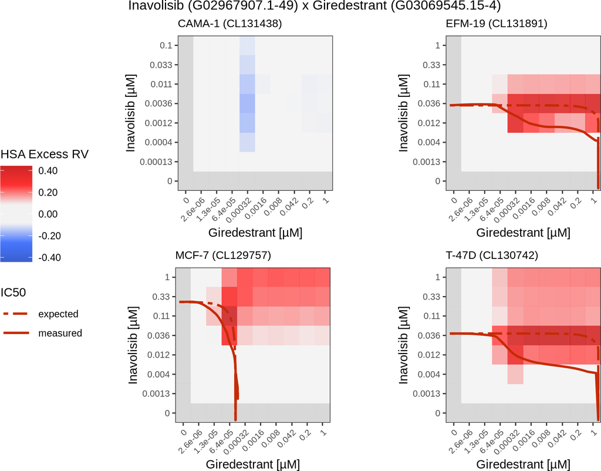

#### 5.7.2.2 GR Value

##### 5.7.2.2.1 Everolimus x Giredestrant

🔍 Zoom In for Details

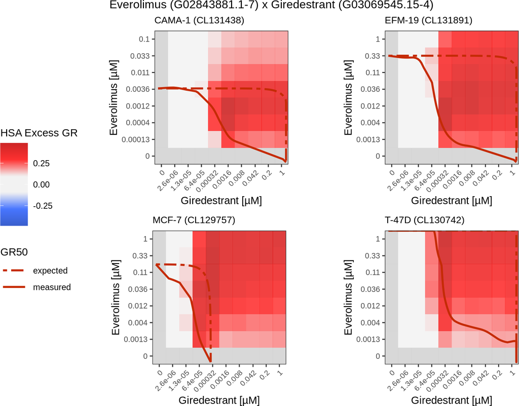

##### 5.7.2.2.2 Inavolisib x Giredestrant

🔍 Zoom In for Details

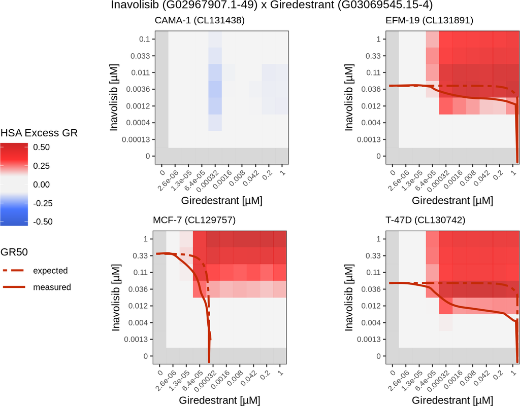

### 5.7.3 Bliss Excess

#### 5.7.3.1 Relative Viability

##### 5.7.3.1.1 Everolimus x Giredestrant

🔍 Zoom In for Details

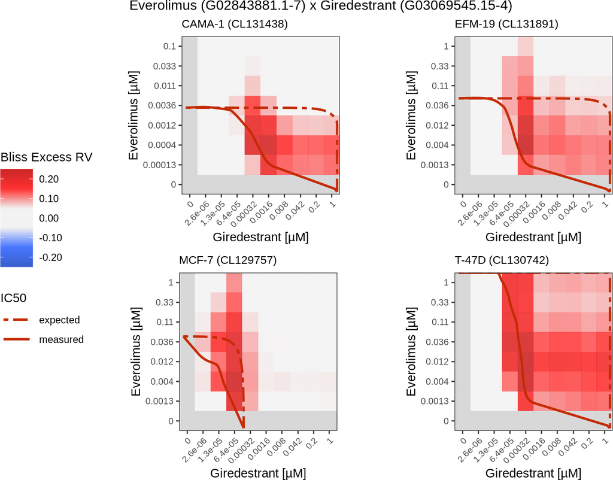

##### 5.7.3.1.2 Inavolisib x Giredestrant

🔍 Zoom In for Details

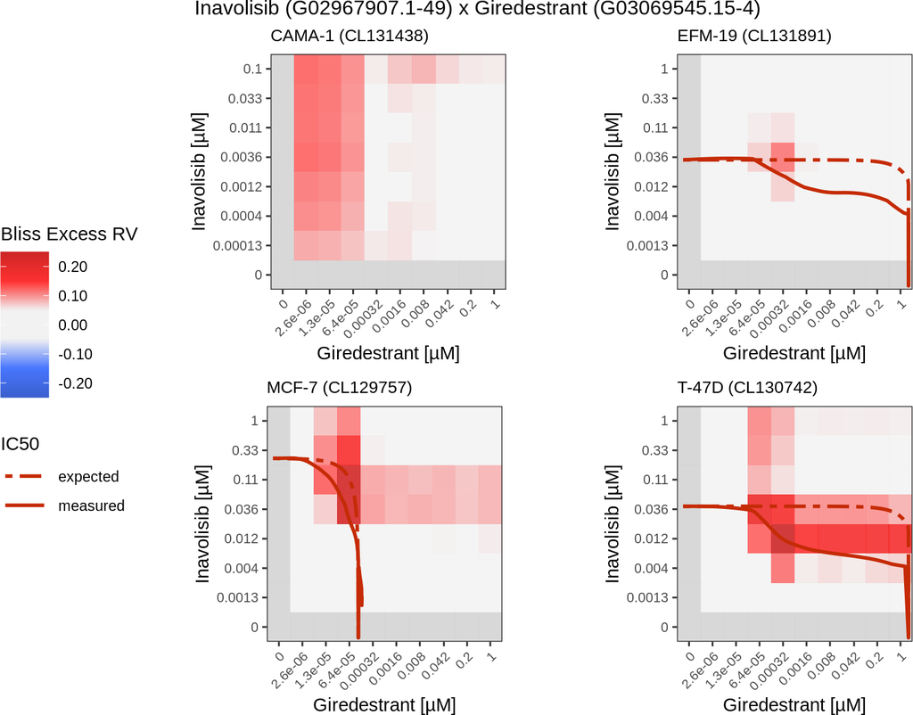

#### 5.7.3.2 GR Value

##### 5.7.3.2.1 Everolimus x Giredestrant

🔍 Zoom In for Details

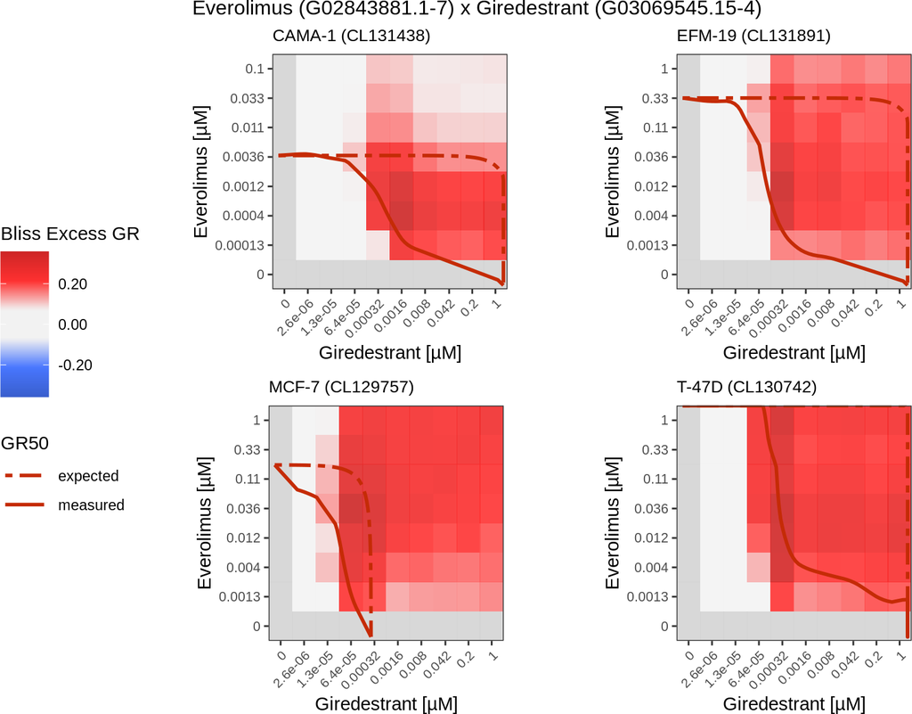

##### 5.7.3.2.2 Inavolisib x Giredestrant

🔍 Zoom In for Details

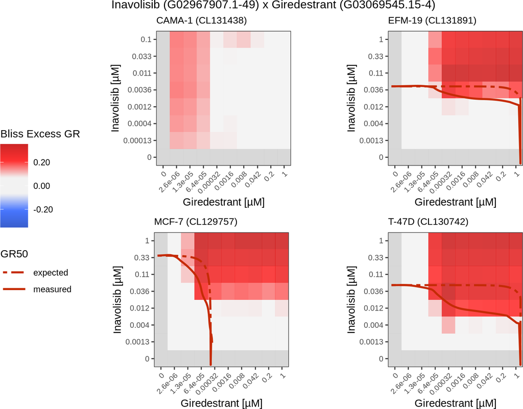

## 5.8 Data Analysis of Fitted Metrics - Combination Data

These plots provide a high-level summary of the final synergy scores (e.g., Bliss Score, HSA Score) to help identify the most interesting combinations and cell lines from the screen.

### 5.8.1 Heatmaps

These heatmaps show the final synergy score for each drug combination (rows) across all cell lines (columns).

**What to look for:**

- **Overall Patterns:** Look for “hot” blocks (often red/orange), which indicate a group of drug combinations that are synergistic in a group of cell lines. Conversely, “cold” blocks (often blue) indicate antagonism.
- **Specific Hits:** Identify individual bright red cells to find the most synergistic drug-cell line “hits” in the screen.
- **Clustering:** Pay attention to how the rows (drug combinations) and columns (cell lines) are clustered. Do drugs with similar mechanisms of action cluster together? Do cell lines from the same tissue type show similar synergy profiles?

```r
combo_metrics <- data.table(
  expand.grid(normalization_type = c("GR", "RV"),
              metric = c("hsa_score", "bliss_score"),
              stringsAsFactors = FALSE))
combo_metrics$hm_title <- pmap(combo_metrics, get_hm_title)

annotation_manual_col <-
  unique(response_metrics_scores[,.SD, .SDcols = c("CellLineName", "Tissue")])
annotation_manual_row <-
  unique(response_metrics_scores[,.SD, .SDcols = c("DrugName", "DrugName_2", "drug_moa", "drug_moa_2")])
annotation_map <- get_ann_color_map(
  unique(response_metrics_scores[,.SD, .SDcols = c("Tissue", "drug_moa", "drug_moa_2")]))

ls_plt_RV <- pmap(combo_metrics[normalization_type == "RV", ],
                  pheatmap_with_anno_combo,
                  dt_scores = response_metrics_scores,
                  annotation_row = annotation_manual_row,
                  annotation_col = annotation_manual_col,
                  annotation_colors = annotation_map)
names(ls_plt_RV) <- combo_metrics[normalization_type == "RV", ]$hm_title
```

```r
ls_plt_GR <- pmap(combo_metrics[normalization_type == "GR", ],
                  pheatmap_with_anno_combo,
                  dt_scores = response_metrics_scores,
                  annotation_row = annotation_manual_row,
                  annotation_col = annotation_manual_col,
                  annotation_colors = annotation_map)
names(ls_plt_GR) <- combo_metrics[normalization_type == "GR", ]$hm_title
```

#### 5.8.1.1 Relative Viability

##### 5.8.1.1.1 HSA Score RV

🔍 Zoom In for Details

💾 Download Table

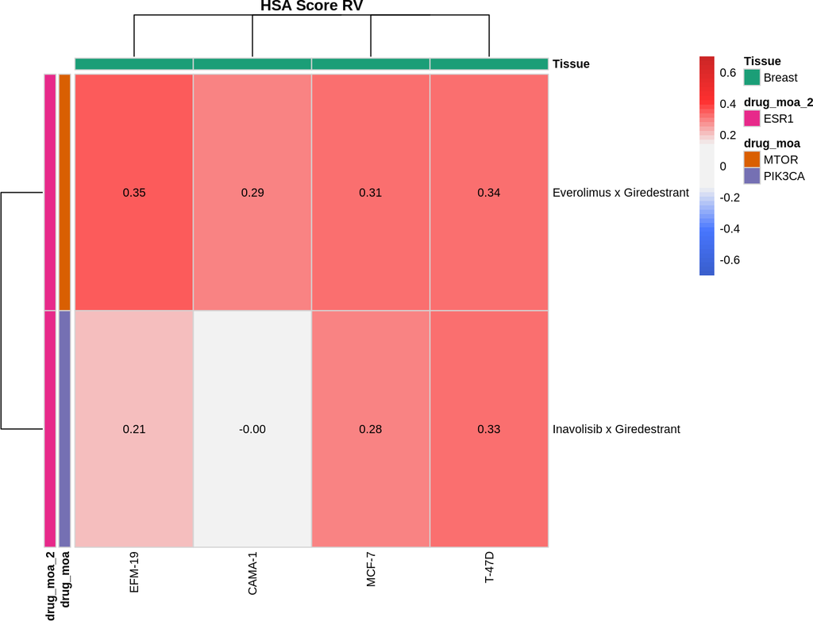

##### 5.8.1.1.2 Bliss Score RV

🔍 Zoom In for Details

💾 Download Table

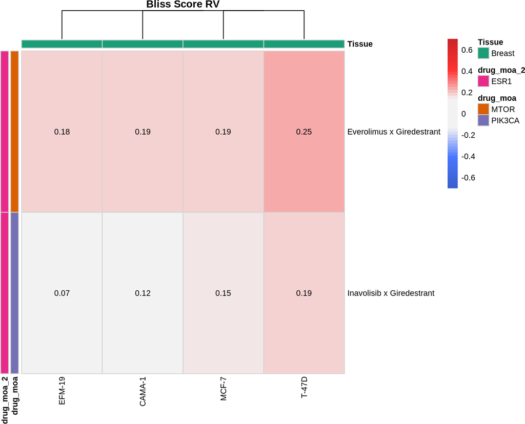

#### 5.8.1.2 GR Value

##### 5.8.1.2.1 HSA Score GR

🔍 Zoom In for Details

💾 Download Table

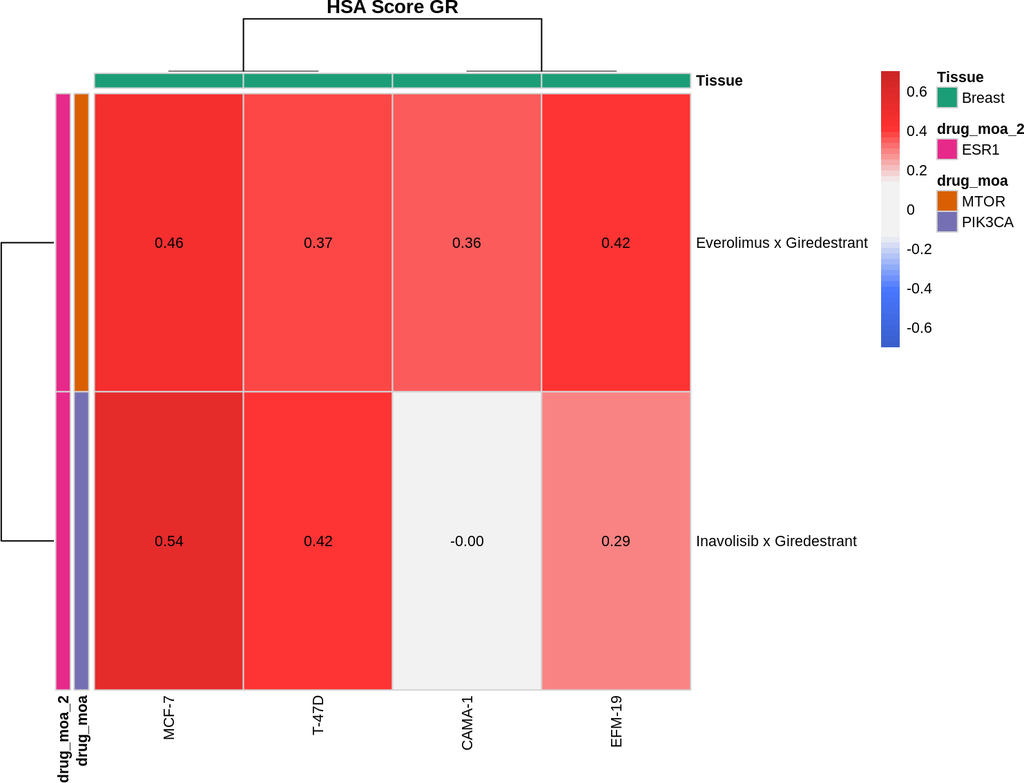

##### 5.8.1.2.2 Bliss Score GR

🔍 Zoom In for Details

💾 Download Table

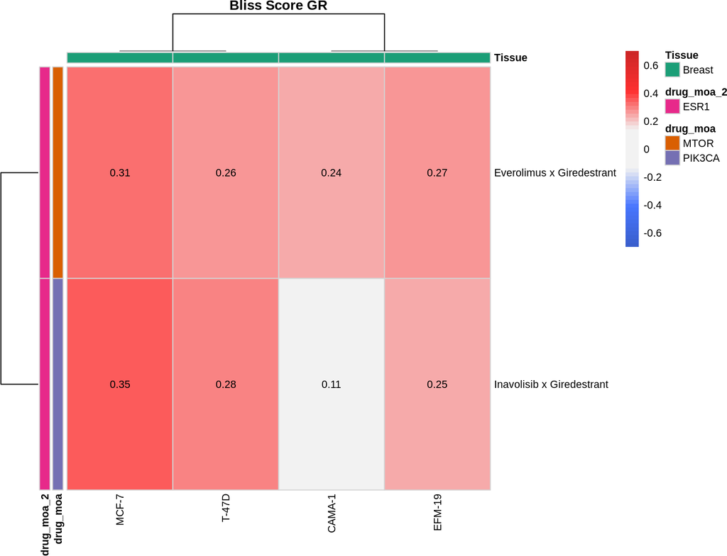

### 5.8.2 Boxplots by Cell Lines

These boxplots show the distribution of a given metric (i.e., HSA or Bliss score) across all treatments, grouped by each cell line.

**What to look for:**

- **Compare Medians:** Look for cell lines with boxplots that have a significantly lower median value (for metrics like IC50, this indicates overall higher sensitivity) or a higher median value (for synergy scores, this indicates a greater tendency for synergistic responses).
- **Examine Spread (Interquartile Range):** A wide boxplot for a particular cell line means its response to different drugs is highly variable. A narrow boxplot means it responds more uniformly to the drug panel.
- **Identify Outliers:** Individual points outside the whiskers can highlight a specific drug that has an exceptionally strong (or weak) effect on that cell line compared to the others.

```r
# metrics
metrics <- data.table(
  expand.grid(normalization_type = c("GR", "RV"),
              metric = c("hsa_score", "bliss_score"),
              stringsAsFactors = FALSE))

ls_plt_RV <- pmap(metrics[normalization_type == "RV", ],
                  plot_boxplot_metric_combo_by_CLs,
                  dt_scores = response_metrics_scores,
                  colored_pts_flag = TRUE)
names(ls_plt_RV) <- unlist(pmap(metrics[normalization_type == "RV", ], get_hm_title))
```

```r
ls_plt_GR <- pmap(metrics[normalization_type == "GR", ],
                  plot_boxplot_metric_combo_by_CLs,
                  dt_scores = response_metrics_scores,
                  colored_pts_flag = TRUE)
names(ls_plt_GR) <- unlist(pmap(metrics[normalization_type == "GR", ], get_hm_title))
```

#### 5.8.2.1 Relative Viability

##### 5.8.2.1.1 HSA Score RV

🔍 Zoom In for Details

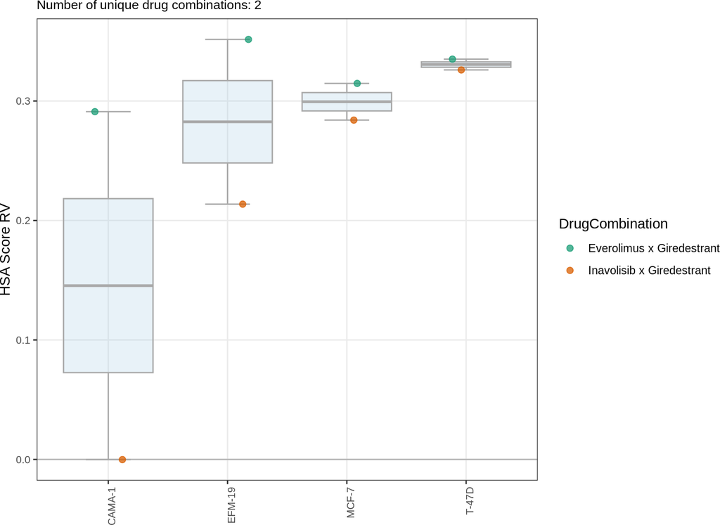

##### 5.8.2.1.2 Bliss Score RV

🔍 Zoom In for Details

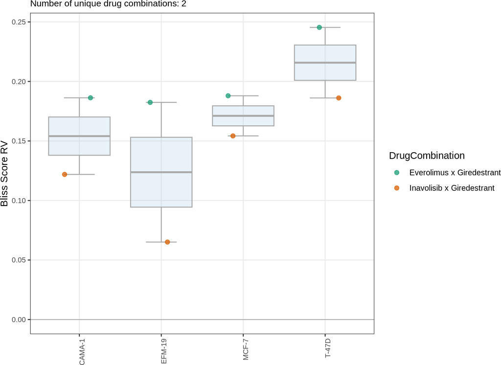

#### 5.8.2.2 GR Value

##### 5.8.2.2.1 HSA Score GR

🔍 Zoom In for Details

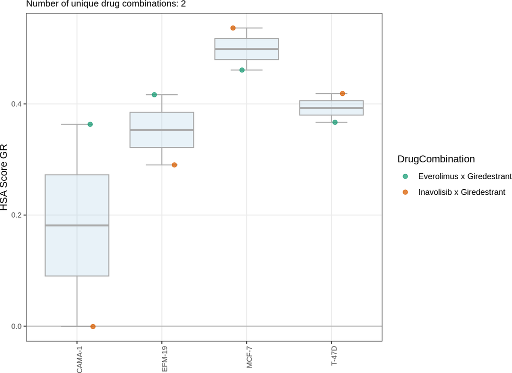

##### 5.8.2.2.2 Bliss Score GR

🔍 Zoom In for Details

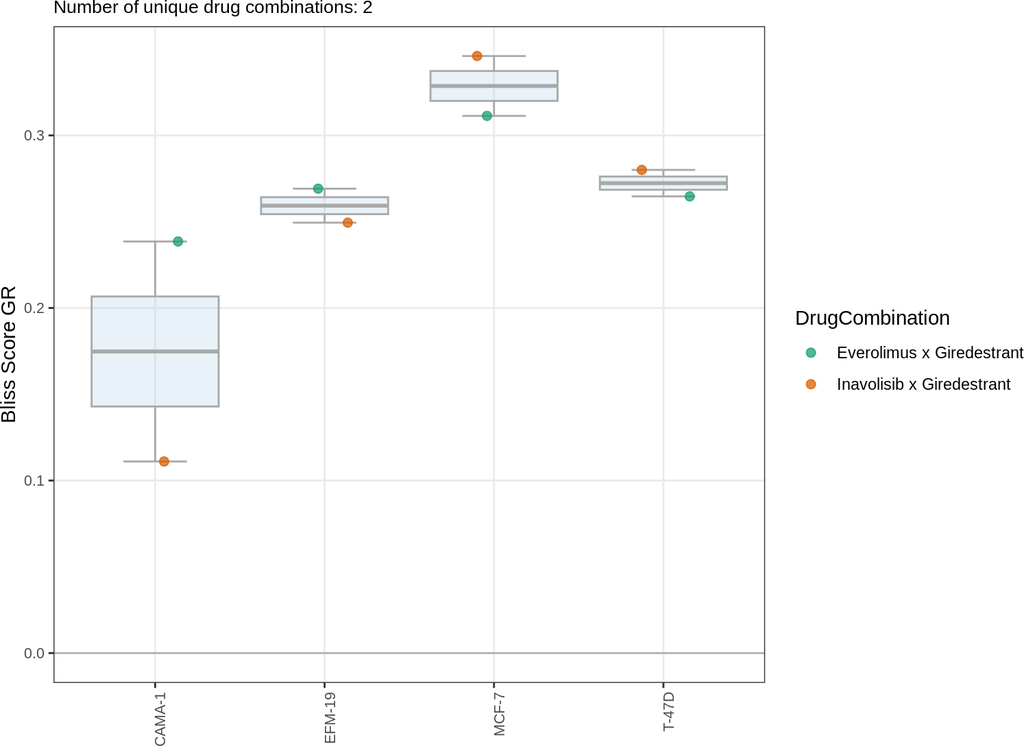

### 5.8.3 Boxplots by Drugs

These boxplots show the distribution of a given metric (i.e., HSA or Bliss score) across all cell lines, grouped by each drug or drug combination.

**What to look for:**

- **Compare Medians:** Use these plots to rank the drugs or combinations. A drug with a boxplot shifted to a lower median IC50 is, on average, more potent across the entire cell line panel. For synergy scores, a combination with a boxplot shifted significantly above zero is, on average, more synergistic.
- **Examine Spread (Interquartile Range):** A wide boxplot for a drug means its effectiveness varies greatly across different cell lines (i.e., it has a selective effect). A narrow boxplot means the drug has a similar effect on most cell lines.
- **Identify Outliers:** Outliers can point to specific cell lines that are exceptionally sensitive or resistant to that particular drug.

```r
# metrics
metrics <- data.table(
  expand.grid(normalization_type = c("GR", "RV"),
              metric = c("hsa_score", "bliss_score"),
              stringsAsFactors = FALSE))

ls_plt_RV <- pmap(metrics[normalization_type == "RV", ],
                  plot_boxplot_metric_combo_by_drugs,
                  dt_scores = response_metrics_scores,
                  colored_pts_flag = TRUE)
names(ls_plt_RV) <- unlist(pmap(metrics[normalization_type == "RV", ], get_hm_title))
```

```r
ls_plt_GR <- pmap(metrics[normalization_type == "GR", ],
                  plot_boxplot_metric_combo_by_drugs,
                  dt_scores = response_metrics_scores,
                  colored_pts_flag = TRUE)
names(ls_plt_GR) <- unlist(pmap(metrics[normalization_type == "GR", ], get_hm_title))
```

#### 5.8.3.1 Relative Viability

##### 5.8.3.1.1 HSA Score RV

🔍 Zoom In for Details

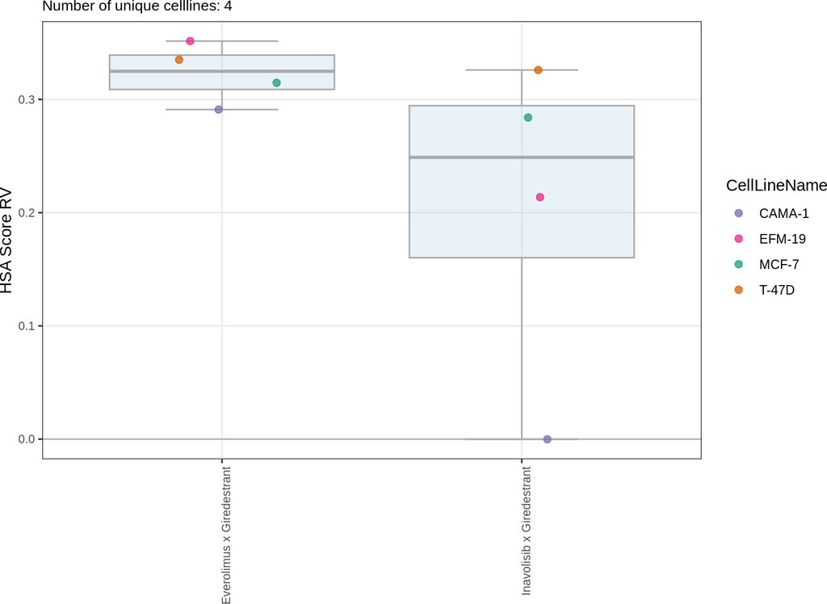

##### 5.8.3.1.2 Bliss Score RV

🔍 Zoom In for Details

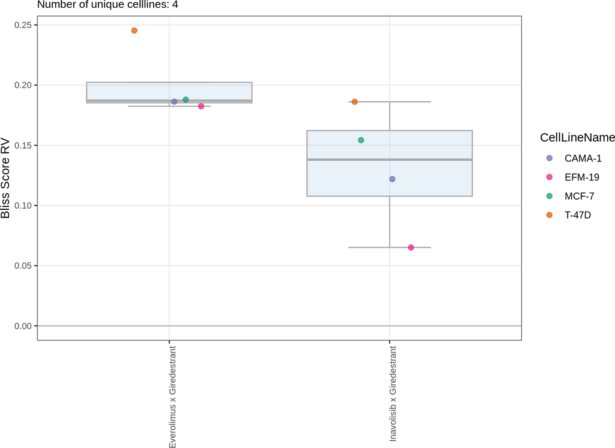

#### 5.8.3.2 GR Value

##### 5.8.3.2.1 HSA Score GR

🔍 Zoom In for Details

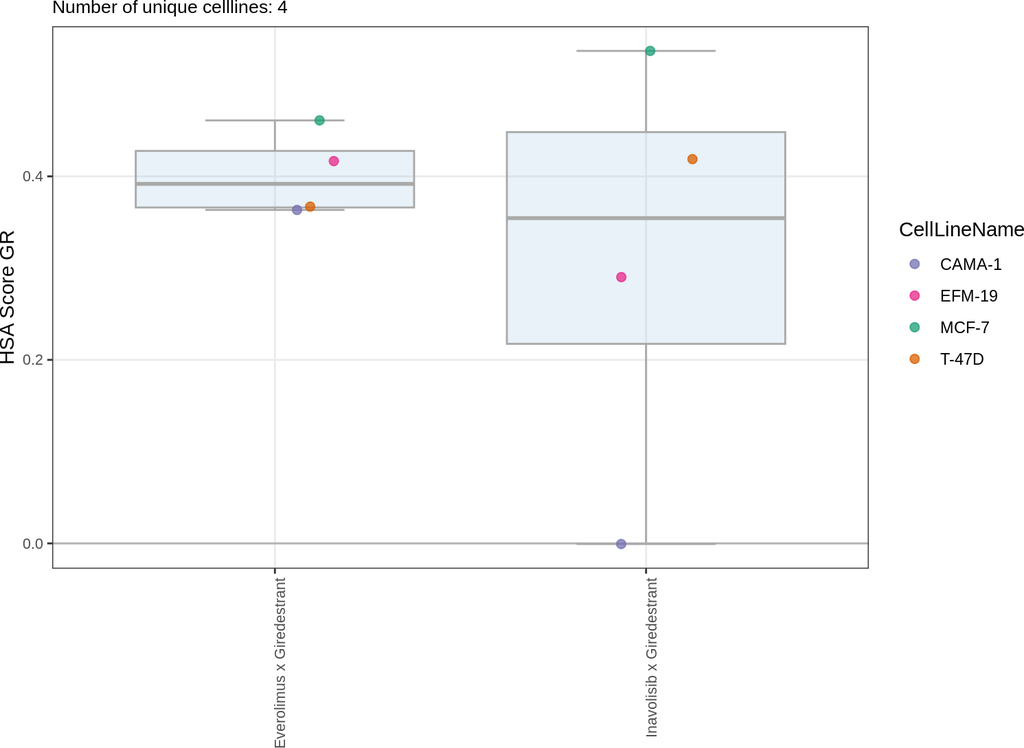

##### 5.8.3.2.2 Bliss Score GR

🔍 Zoom In for Details

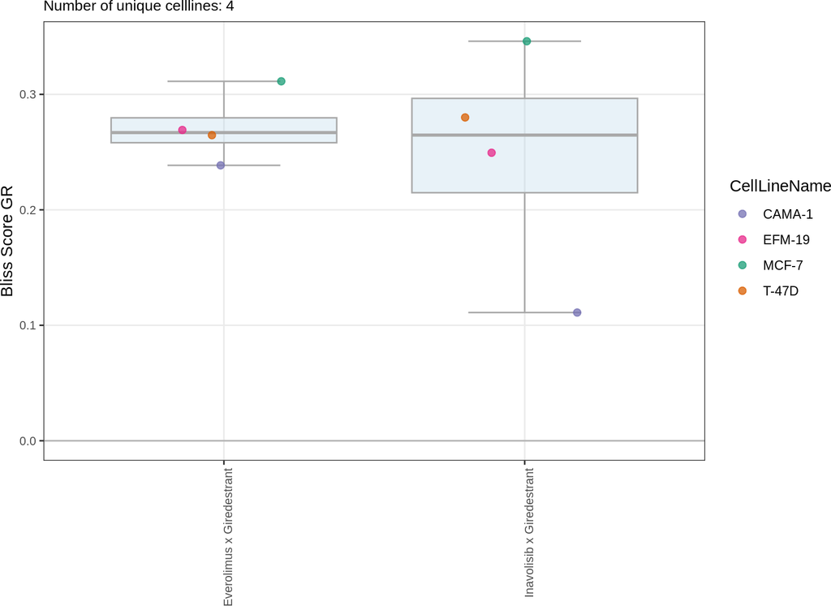

### 5.8.4 Boxplots by Tissue

These boxplots show the distribution of a given metric (i.e., HSA or Bliss score) across all treatments, grouped by each tissue.

**What to look for:**

- **Compare Medians:** Look for tissues with boxplots that have a significantly lower median value (for metrics like IC50, this indicates overall higher sensitivity) or a higher median value (for synergy scores, this indicates a greater tendency for synergistic responses).
- **Examine Spread (Interquartile Range):** A wide boxplot for a particular tissue means its response to different drugs is highly variable. A narrow boxplot means it responds more uniformly to the drug panel.
- **Identify Outliers:** Individual points outside the whiskers can highlight a specific drug that has an exceptionally strong (or weak) effect on that tissue compared to the others.

```r
tab_grid <-
  unique(response_metrics_scores[, .SD, .SDcols = c("DrugName", "DrugName_2")])
setorder(tab_grid)

ls_names <- sprintf("%s x %s", tab_grid$DrugName, tab_grid$DrugName_2)
ls_names <- vapply(ls_names, function(i) escape_special_characters(i),
                   FUN.VALUE = character(1), USE.NAMES = FALSE)
```

```r
ls_plt_RV <- lapply(c("hsa_score", "bliss_score"), function(metric) {
  ls_ <- pmap(tab_grid, function(DrugName, DrugName_2) {
    plot_boxplot_metric_combo_by_grp(
      dt_scores = response_metrics_scores,
      selection_var = "DrugName",
      selection_name = c(DrugName, DrugName_2),
      group_var = "Tissue",
      normalization_type = "RV",
      metric = metric,
      grouped_flag = TRUE,
      named_n = 15,
      named_n_mode = "top")
  })
  names(ls_) <- ls_names
  ls_
})
names(ls_plt_RV) <- unlist(pmap(metrics[normalization_type == "RV", ], get_hm_title))
```

```r
ls_plt_GR <- lapply(c("hsa_score", "bliss_score"), function(metric) {
  ls_ <- pmap(tab_grid, function(DrugName, DrugName_2) {
    plot_boxplot_metric_combo_by_grp(
      dt_scores = response_metrics_scores,
      selection_var = "DrugName",
      selection_name = c(DrugName, DrugName_2),
      group_var = "Tissue",
      normalization_type = "GR",
      metric = metric,
      grouped_flag = TRUE,
      named_n = 15,
      named_n_mode = "top")
  })
  names(ls_) <- ls_names
  ls_
})
names(ls_plt_GR) <- unlist(pmap(metrics[normalization_type == "GR", ], get_hm_title))
```

#### 5.8.4.1 Relative Viability

##### 5.8.4.1.1 HSA Score RV

###### 5.8.4.1.1.1 Everolimus x Giredestrant

🔍 Zoom In for Details

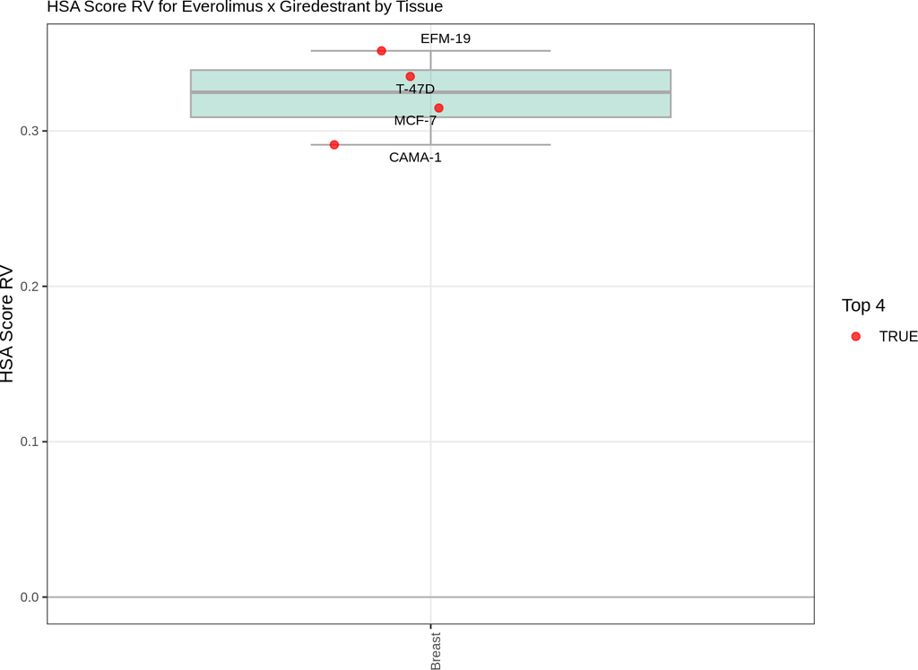

###### 5.8.4.1.1.2 Inavolisib x Giredestrant

🔍 Zoom In for Details

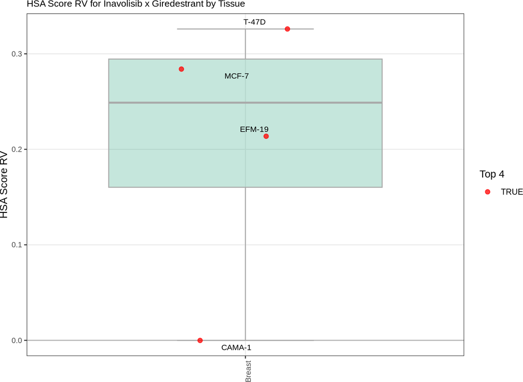